# Laboratorium 5

Rozwiązanie zadania 1

Author

Dariusz Majerek

Published

March 26, 2025

# Przygotowanie danych

```r
library(tidymodels)
library(titanic)

glimpse(titanic_train)
```

```
Rows: 891
Columns: 12
$ PassengerId <int> 1, 2, 3, 4, 5, 6, 7, 8, 9, 10, 11, 12, 13, 14, 15, 16, 17,…
$ Survived    <int> 0, 1, 1, 1, 0, 0, 0, 0, 1, 1, 1, 1, 0, 0, 0, 1, 0, 1, 0, 1…
$ Pclass      <int> 3, 1, 3, 1, 3, 3, 1, 3, 3, 2, 3, 1, 3, 3, 3, 2, 3, 2, 3, 3…
$ Name        <chr> "Braund, Mr. Owen Harris", "Cumings, Mrs. John Bradley (Fl…
$ Sex         <chr> "male", "female", "female", "female", "male", "male", "mal…
$ Age         <dbl> 22, 38, 26, 35, 35, NA, 54, 2, 27, 14, 4, 58, 20, 39, 14, …
$ SibSp       <int> 1, 1, 0, 1, 0, 0, 0, 3, 0, 1, 1, 0, 0, 1, 0, 0, 4, 0, 1, 0…
$ Parch       <int> 0, 0, 0, 0, 0, 0, 0, 1, 2, 0, 1, 0, 0, 5, 0, 0, 1, 0, 0, 0…
$ Ticket      <chr> "A/5 21171", "PC 17599", "STON/O2. 3101282", "113803", "37…
$ Fare        <dbl> 7.2500, 71.2833, 7.9250, 53.1000, 8.0500, 8.4583, 51.8625,…
$ Cabin       <chr> "", "C85", "", "C123", "", "", "E46", "", "", "", "G6", "C…
$ Embarked    <chr> "S", "C", "S", "S", "S", "Q", "S", "S", "S", "C", "S", "S"…
```

Ponieważ zmienna zależna `Suvirved` jest zmienną binarną (kodowaną numerycznie), to zamienimy ją na faktor.

```r
titanic_train <- titanic_train %>%
  mutate(Survived = factor(Survived, levels = c(0, 1), labels = c("No", "Yes")))

set.seed(44)
split <- initial_split(titanic_train, prop = 0.7, strata = Survived)
train <- training(split)
test <- testing(split)
```

Celem zadania nie jest ekstrakcja cech dlatego pominiemy ten krok i przejdziemy od razu do modelowania na pełnym zestawie zmiennych, z wyjątkiem zmiennych `Name`, `Ticket` i `Cabin`, które są bardzo unikalne dla obserwacji i mogłyby przeszkodzić w uczeniu modelu regresji logistycznej.

```r
train <- select(train, -Name, -Ticket, -Cabin)
test <- select(test, -Name, -Ticket, -Cabin)
```

# Budowa modeli

Zaczniemy od przygotowania przepisów na modele.

```r
reg_log <- logistic_reg() %>%
  set_engine("glm") %>%
  set_mode("classification")

rpart <- decision_tree() %>%
  set_engine("rpart", model = TRUE) %>%
  set_mode("classification")
```

# Uczenie modeli na zbiorach treningowych

Zaczniemy od modelu regresji logistycznej.

```r
reg_log_fit <- reg_log %>%
  fit(Survived ~ ., data = train)

reg_log_fit %>%
  tidy()
```

```
# A tibble: 11 × 5
   term           estimate  std.error statistic  p.value
   <chr>             <dbl>      <dbl>     <dbl>    <dbl>
 1 (Intercept)  17.1       615.          0.0278 9.78e- 1
 2 PassengerId   0.0000876   0.000459    0.191  8.49e- 1
 3 Pclass       -1.16        0.199      -5.81   6.08e- 9
 4 Sexmale      -2.38        0.262      -9.07   1.16e-19
 5 Age          -0.0332      0.00957    -3.47   5.16e- 4
 6 SibSp        -0.315       0.147      -2.14   3.26e- 2
 7 Parch        -0.118       0.145      -0.816  4.14e- 1
 8 Fare          0.00354     0.00381     0.930  3.53e- 1
 9 EmbarkedC   -12.2       615.         -0.0198 9.84e- 1
10 EmbarkedQ   -13.0       615.         -0.0211 9.83e- 1
11 EmbarkedS   -12.5       615.         -0.0203 9.84e- 1
```

Teraz dopasujemy model drzewa decyzyjnego.

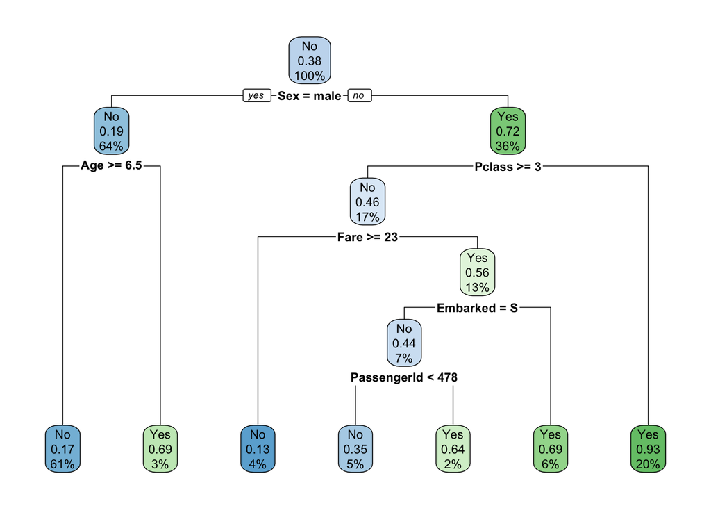

```r
rpart_fit <- rpart %>%
  fit(Survived ~ ., data = train)

library(rpart.plot)
rpart_fit %>%
  extract_fit_engine() %>%
  rpart.plot()
```